# Rare Disease Celltyping

GPT phenotype annotations

Brian M. Schilder

# Import annotations

We have stored the GPT-generated annotations on GitHub Releases, and distribute them via the `gpt_annot_read` function.

```r
annot <- HPOExplorer::gpt_annot_read()
```

```
## Reading cached RDS file: phenotype_to_genes.txt
```

```
## + Version: v2023-10-09
```

```
## Reading in GPT annotations for 10,648 phenotypes.
```

```r
knitr::kable(head(annot))
```

| hpo_name | intellectual_disability | intellectual_disability_justification | death | death_justification | impaired_mobility | impaired_mobility_justification | physical_malformations | physical_malformations_justification | blindness | blindness_justification | sensory_impairments | sensory_impairments_justification | immunodeficiency | immunodeficiency_justification | cancer | cancer_justification | reduced_fertility | reduced_fertility_justification | congenital_onset | congenital_onset_justification | hpo_id | pheno_count |
| --- | --- | --- | --- | --- | --- | --- | --- | --- | --- | --- | --- | --- | --- | --- | --- | --- | --- | --- | --- | --- | --- | --- |
| 1-2 toe complete cutaneous syndactyly | never | This condition affects the physical structure of the toes, not cognitive function. | rarely | Death could occur if complications arise during surgery. | often | The affected individual may have difficulty walking. | always | The toes are physically fused together. | never | This condition does not affect vision. | never | This condition does not affect sensory function. | never | This condition does not affect the immune system. | never | This condition does not increase the risk of cancer. | never | This condition does not affect fertility. | always | This condition is present at birth. | HP:0005767 | 1 |
| 1-2 toe syndactyly | never | No direct link between toe syndactyly and intellectual disability | never | Toe syndactyly does not directly cause death | rarely | May cause minor mobility issues in some cases | always | Toe syndactyly is a physical malformation | never | No direct link between toe syndactyly and blindness | never | No direct link between toe syndactyly and sensory impairments | never | No direct link between toe syndactyly and immunodeficiency | never | No direct link between toe syndactyly and cancer | never | No direct link between toe syndactyly and reduced fertility | always | Toe syndactyly is present at birth | HP:0010711 | 1 |
| 1-3 toe syndactyly | never | No relation to cognitive function. | never | No direct cause of death. | often | Can hinder normal walking or foot function. | always | Direct manifestation of the condition. | never | No relation to vision. | never | No sensory impairments other than the physical fusion. | never | Not related. | never | No relation to cancer. | never | No direct relation to fertility. | always | Is congenital in nature. | HP:0001459 | 1 |
| 1-4 finger syndactyly | never | No direct link between finger syndactyly and intellectual disability | never | Finger syndactyly does not directly cause death | often | Can cause significant mobility issues depending on severity | always | Finger syndactyly is a physical malformation | never | No direct link between finger syndactyly and blindness | never | No direct link between finger syndactyly and sensory impairments | never | No direct link between finger syndactyly and immunodeficiency | never | No direct link between finger syndactyly and cancer | never | No direct link between finger syndactyly and reduced fertility | always | Finger syndactyly is present at birth | HP:0010707 | 1 |
| 1-4 toe syndactyly | never | This condition affects the physical structure of the toes, not the brain. | never | This condition does not directly cause death. | often | The fusion of toes can lead to balance and walking issues. | always | Syndactyly is a physical malformation where two or more digits are fused together. | never | This condition affects the physical structure of the toes, not the eyes. | rarely | While the condition can potentially affect the nerves in the toes, it is not commonly associated with sensory impairments. | never | This condition does not affect the immune system. | never | This condition does not cause cancer. | never | This condition does not affect fertility. | always | Syndactyly is a congenital condition, meaning it is present at birth. | HP:0010712 | 1 |
| 1-5 finger complete cutaneous syndactyly | never | No direct correlation with intellectual capacities. | never | It is not a condition that directly induces mortality. | often | Syndactyly involves fusion of digits, often leading to mobility issues. | always | Syndactyly itself is a physical malformation. | never | There is no impact on the visual system. | rarely | While general sensory faculties are intact, fine touch discrimination may be rarely affected. | never | No impact on the immune system’s functionality. | never | No known association with cancer. | never | Fertility is not impacted by this physical malformation. | always | This is a congenital condition and is present from birth. | HP:0006088 | 1 |

Some phenotype were annotated multiple times, thoughh most were only annotated once:

```r
table(annot$pheno_count)
```

```
##
##     1     2     3
## 10378   478    93
```

# Validate

We can identify true positives by identifying phenotypes that fall within specific branches HPO that would guarantee them to have at least a “often” as a response. For example, blindness phenotypes should often be associated with blindness.

You can modify the searches with the `search_hpo` function.

```r
query_hits <- HPOExplorer::search_hpo()
```

```
## ℹ All local files already up-to-date!
```

```
## Number of phenotype gits per query group:
```

```
##  - intellectual_disability: 7
##  - impaired_mobility: 294
##  - physical_malformations: 105
##  - blindness: 2
##  - sensory_impairments: 256
##  - immunodeficiency: 10
##  - cancer: 697
##  - reduced_fertility: 6
```

```r
lapply(query_hits,head)
```

```
## $intellectual_disability
## [1] "HP:0001249" "HP:0001256" "HP:0002187" "HP:0002342" "HP:0006887"
## [6] "HP:0006889"
##
## $impaired_mobility
## [1] "HP:0011442" "HP:0100022" "HP:0000473" "HP:0001336" "HP:0001337"
## [6] "HP:0002071"
##
## $physical_malformations
## [1] "HP:0001305" "HP:0002308" "HP:0002390" "HP:0002408" "HP:0002438"
## [6] "HP:0002564"
##
## $blindness
## [1] "HP:0000618" "HP:0007875"
##
## $sensory_impairments
## [1] "HP:0000223" "HP:0000364" "HP:0000504" "HP:0003474" "HP:0004408"
## [6] "HP:0000224"
##
## $immunodeficiency
## [1] "HP:0001400" "HP:0002721" "HP:0002755" "HP:0003553" "HP:0004430"
## [6] "HP:0005352"
##
## $cancer
## [1] "HP:0002664" "HP:0002894" "HP:0002896" "HP:0002898" "HP:0003003"
## [6] "HP:0004375"
##
## $reduced_fertility
## [1] "HP:0000144" "HP:0000868" "HP:0012041" "HP:0000789" "HP:0008222"
## [6] "HP:0003251"
```

```r
checks <- HPOExplorer::gpt_annot_check(annot = annot,
                                       query_hits = query_hits)
```

## Check consistency

When there’s >1 set of annotations for a given phenotype, how consistent are they? (0-1 scale).

```r
sort(unlist(checks$annot_consist))
```

```
##     sensory_impairments intellectual_disability                  cancer
##               0.7703704               0.8259259               0.8370370
##       reduced_fertility                   death       impaired_mobility
##               0.8407407               0.8703704               0.8740741
##  physical_malformations        immunodeficiency        congenital_onset
##               0.8962963               0.9000000               0.9185185
##               blindness             pheno_count
##               0.9296296               1.0000000
```

## Checkable rate

What proportion of annotated phenotypes can be validated (per annotation column)?

```r
sort(checks$checkable_rate)
```

```
##               blindness        immunodeficiency       reduced_fertility
##            0.0001826651            0.0005479953            0.0005479953
## intellectual_disability  physical_malformations     sensory_impairments
##            0.0006393278            0.0054799525            0.0138825464
##       impaired_mobility                  cancer
##            0.0231071331            0.0416476391
```

What is the absolute number of phenotypes that can be validated (per annotation column)?

```r
sort(checks$checkable_count)
```

```
##               blindness        immunodeficiency       reduced_fertility
##                       2                       6                       6
## intellectual_disability  physical_malformations     sensory_impairments
##                       7                      60                     152
##       impaired_mobility                  cancer
##                     253                     456
```

## True positive rate

For the phenotypes that can be validated, how many of them have the expected values (per annotation column).

```r
sort(checks$true_pos_rate)
```

```
##       impaired_mobility                  cancer  physical_malformations
##               0.8853755               0.9385965               0.9666667
##     sensory_impairments intellectual_disability               blindness
##               0.9868421               1.0000000               1.0000000
##        immunodeficiency       reduced_fertility
##               1.0000000               1.0000000
```

## Summary plot

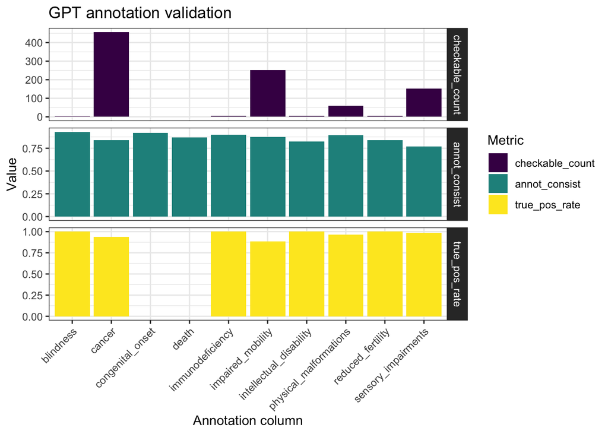

```r
checks$plot
```

# Codify severity

The `gpt_annot_codify` function performs a series of steps to clean, filter, and quantify the responses.

```r
coded <- HPOExplorer::gpt_annot_codify(annot = annot)
```

First, it codifies each response from 0-4:

```r
code_dict = c(
               "never"=0,
               "rarely"=1,
               "varies"=2,
               "often"=3,
               "always"=4
             )
```

Then it multiplies those response values by the severity of their respective annotation column. This captures the facts that some annotations have more serious consequences than others (e.g death >> reduced_fertility).

```r
 tiers_dict = list(
                   intellectual_disability=1,
                   death=1,
                   impaired_mobility=2,
                   physical_malformations=2,
                   blindness=3,
                   sensory_impairments=3,
                   immunodeficiency=3,
                   cancer=3,
                   reduced_fertility=4
                 )
```

Next, it takes the multiplied values across all columns and computes an average score per phenotypes. This is then normalised by the theoretical maximum severity score, so that all phenotypes are on a 0-100 severity scale (where 100 is the most severe phenotype possible). This normalised score is added as a new column named “severity_score_gpt”.

Finally, the results are sorted by “severity_score_gpt” so that the most severe phenotypes are at the top of the table.

```r
knitr::kable(head(coded$annot_weighted))
```

| intellectual_disability | death | impaired_mobility | physical_malformations | blindness | sensory_impairments | immunodeficiency | cancer | reduced_fertility | hpo_id | severity_score_gpt | hpo_name |
| --- | --- | --- | --- | --- | --- | --- | --- | --- | --- | --- | --- |
| 16 | 16 | 12 | 12 | 6 | 8 | 6 | 2 | 3 | HP:0007367 | 51.26582 | Atrophy/Degeneration affecting the central nervous system |
| 12 | 12 | 9 | 9 | 6 | 6 | 6 | 6 | 3 | HP:0000118 | 43.67089 | Phenotypic abnormality |
| 12 | 12 | 9 | 9 | 2 | 6 | 6 | 6 | 3 | HP:0011463 | 41.13924 | Childhood onset |
| 12 | 12 | 9 | 9 | 2 | 6 | 6 | 6 | 3 | HP:0011462 | 41.13924 | Young adult onset |
| 12 | 12 | 9 | 12 | 2 | 6 | 2 | 8 | 0 | HP:0009592 | 39.87342 | Astrocytoma |
| 16 | 12 | 9 | 9 | 6 | 6 | 2 | 2 | 1 | HP:0007369 | 39.87342 | Atrophy/Degeneration affecting the cerebrum |

### Download coded data

```r
downloadthis::download_this(.data = coded$annot_weighted,
                            output_name = "gpt_annot_plot_data",
                            csv2 = FALSE)
```

# Plot

```r
plts <- HPOExplorer::gpt_annot_plot(annot = annot)
```

```
## Getting absolute ontology level for 50 HPO IDs.
```

```
## ℹ All local files already up-to-date!
```

```
## Adding level-3 ancestor to each HPO ID.
```

```
## ℹ All local files already up-to-date!
```

```
## Removing remove descendants of: 'Clinical course'
##  -'Sporadic'
##  -'Multifactorial inheritance'
##  -'Inheritance modifier'
##  -'Phenotypic variability'
```

```
## Translating all phenotypes to HPO IDs.
```

```
## + Returning a dictionary of phenotypes (different order as input).
```

```
## Adding level-3 ancestor to each HPO ID.
```

```
## ℹ All local files already up-to-date!
```

## Raw data

```r
knitr::kable(head(plts$data$dat1))
```

| hpo_id | hpo_name | severity_score_gpt | variable | value |
| --- | --- | --- | --- | --- |
| HP:0007367 | Atrophy/Degeneration affecting the central nervous system | 51.26582 | intellectual_disability | always |
| HP:0000118 | Phenotypic abnormality | 43.67089 | intellectual_disability | often |
| HP:0011463 | Childhood onset | 41.13924 | intellectual_disability | often |
| HP:0011462 | Young adult onset | 41.13924 | intellectual_disability | often |
| HP:0009592 | Astrocytoma | 39.87342 | intellectual_disability | often |
| HP:0007369 | Atrophy/Degeneration affecting the cerebrum | 39.87342 | intellectual_disability | always |

## Heatmap

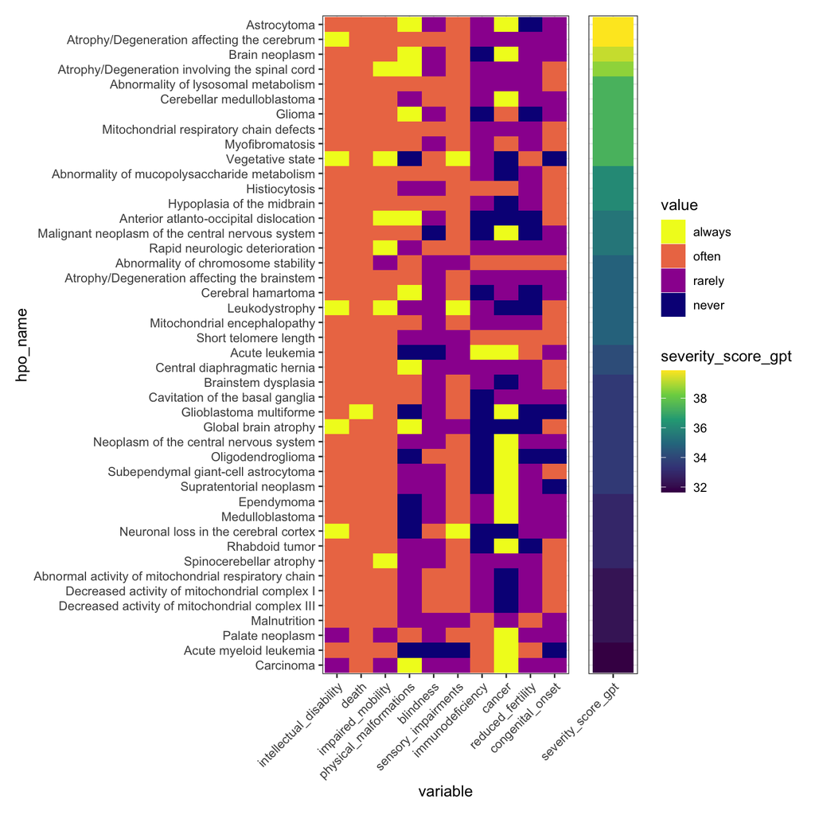

```r
plts$gp0
```

## Barplot

Proportion reponses per annotation column.

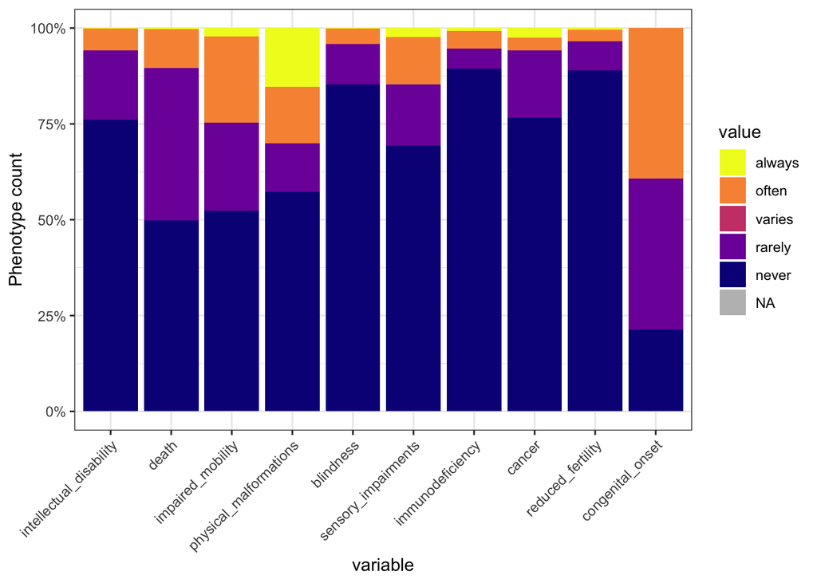

```r
plts$gp1
```

## Boxplots

Responses vs. severity scores.

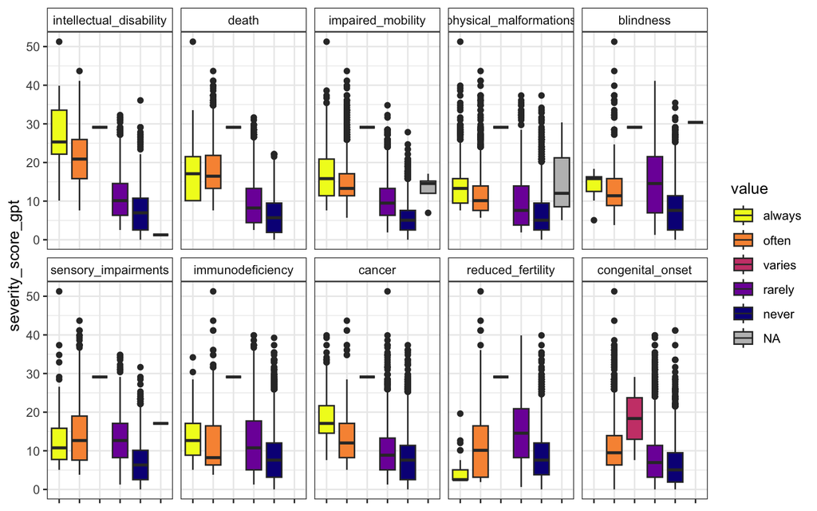

```r
plts$gp2
```

## Histograms

Severity score distributions by HPO branch.

Let’s look at the distribution of GPT severity scores across all phenotypes, grouped by which branch of the HPO those phenotypes belong to.

In red, we show the mean severity score per HPO branch.

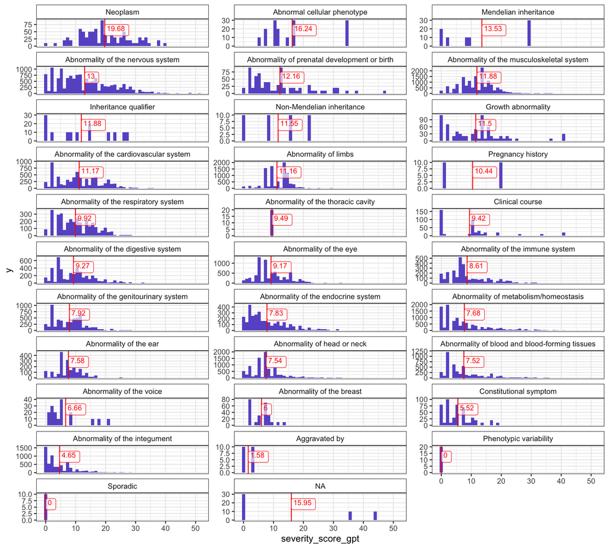

```r
plts$gp3
```